# Tutorial: Descriptive Statistics in R

Dr. Ashraf Uddin

7/18/2025

This R Notebook provides a step-by-step tutorial for calculating and visualizing descriptive statistics using the built-in `iris` dataset.

### Step 1: Load and Inspect Data

First, load your data into your R environment. The `iris` dataset is already available. We’ll inspect its structure to understand the variables we’re working with.

- `head(iris)`: Shows the first 6 rows.
- `str(iris)`: Displays the structure of the dataset.
- `summary(iris)`: Provides a quick statistical summary of each variable.

```r
# Load and inspect the iris dataset
head(iris)
```

|  | Sepal.Length | Sepal.Width | Petal.Length | Petal.Width | Species |
| --- | --- | --- | --- | --- | --- |
| 1 | 5.1 | 3.5 | 1.4 | 0.2 | setosa |
| 2 | 4.9 | 3.0 | 1.4 | 0.2 | setosa |
| 3 | 4.7 | 3.2 | 1.3 | 0.2 | setosa |
| 4 | 4.6 | 3.1 | 1.5 | 0.2 | setosa |
| 5 | 5.0 | 3.6 | 1.4 | 0.2 | setosa |
| 6 | 5.4 | 3.9 | 1.7 | 0.4 | setosa |

```r
str(iris)
```

```
'data.frame':   150 obs. of  5 variables:
 $ Sepal.Length: num  5.1 4.9 4.7 4.6 5 5.4 4.6 5 4.4 4.9 ...
 $ Sepal.Width : num  3.5 3 3.2 3.1 3.6 3.9 3.4 3.4 2.9 3.1 ...
 $ Petal.Length: num  1.4 1.4 1.3 1.5 1.4 1.7 1.4 1.5 1.4 1.5 ...
 $ Petal.Width : num  0.2 0.2 0.2 0.2 0.2 0.4 0.3 0.2 0.2 0.1 ...
 $ Species     : Factor w/ 3 levels "setosa","versicolor",..: 1 1 1 1 1 1 1 1 1 1 ...
```

The summary() function is a great starting point, giving a high-level overview of each column.

```r
# Get a comprehensive summary
summary(iris)
```

```
  Sepal.Length    Sepal.Width
 Min.   :4.300   Min.   :2.000
 1st Qu.:5.100   1st Qu.:2.800
 Median :5.800   Median :3.000
 Mean   :5.843   Mean   :3.057
 3rd Qu.:6.400   3rd Qu.:3.300
 Max.   :7.900   Max.   :4.400
  Petal.Length    Petal.Width
 Min.   :1.000   Min.   :0.100
 1st Qu.:1.600   1st Qu.:0.300
 Median :4.350   Median :1.300
 Mean   :3.758   Mean   :1.199
 3rd Qu.:5.100   3rd Qu.:1.800
 Max.   :6.900   Max.   :2.500
       Species
 setosa    :50
 versicolor:50
 virginica :50
```

### Step 2: Measures of Central Tendency

These statistics describe the center of your data distribution. 🎯

- Mean: The average value.
- Median: The middle value when the data is sorted.
- Mode: The most frequently occurring value.

Let’s calculate these for the Sepal.Length variable.

```r
# Calculate mean
mean(iris$Sepal.Length)
```

```
[1] 5.843333
```

```r
# Calculate median
median(iris$Sepal.Length)
```

```
[1] 5.8
```

```r
# To find the mode, create a table of frequencies
freq_table <- table(iris$Sepal.Length)
# Find the name of the most frequent value
names(freq_table)[which.max(freq_table)]
```

```
[1] "5"
```

### Step 3: Measures of Dispersion (Variability)

These statistics describe the spread or variability of your data.

- Range: The difference between the maximum and minimum values.
- Variance (s 2 ): The average of the squared differences from the Mean.
- Standard Deviation (s): The square root of the variance.
- Interquartile Range (IQR): The range of the middle 50% of your data (Q3−Q1).

```r
# Calculate the range
range_val <- range(iris$Sepal.Length)
max(range_val) - min(range_val)
```

```
[1] 3.6
```

```r
# Calculate variance
var(iris$Sepal.Length)
```

```
[1] 0.6856935
```

```r
# Calculate standard deviation
sd(iris$Sepal.Length)
```

```
[1] 0.8280661
```

```r
# Calculate the Interquartile Range
IQR(iris$Sepal.Length)
```

```
[1] 1.3
```

```r
# Get specific quantiles (e.g., 25th and 75th percentiles)
quantile(iris$Sepal.Length, probs = c(0.25, 0.75))
```

```
25% 75%
5.1 6.4
```

### Step 4: Group-wise Descriptive Statistics

Often, you’ll need to calculate statistics for different subgroups. The dplyr package is perfect for this. If you don’t have it, run install.packages(“dplyr”) in your console once.

```r
library(dplyr)
# Calculate mean, sd, and count for each species
iris %>%
  group_by(Species) %>%
  summarise(
    count = n(),
    mean_sepal_length = mean(Sepal.Length),
    sd_sepal_length = sd(Sepal.Length),
    mean_petal_length = mean(Petal.Length),
    sd_petal_length = sd(Petal.Length)
  )
```

| Species | count | mean_sepal_length | sd_sepal_length | mean_petal_length | sd_petal_length |
| --- | --- | --- | --- | --- | --- |
| setosa | 50 | 5.006 | 0.3524897 | 1.462 | 0.1736640 |
| versicolor | 50 | 5.936 | 0.5161711 | 4.260 | 0.4699110 |
| virginica | 50 | 6.588 | 0.6358796 | 5.552 | 0.5518947 |

## Multivariate Analysis

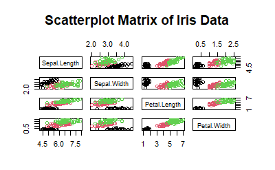

```r
pairs(iris[, 1:4], main = "Scatterplot Matrix of Iris Data", col = iris$Species)
```